# CSCA 5632 Unsupervised Algorithms in Machine Learning Final Project

## Clustering Analysis with Mall Customers Dataset

### 1. Introduction

In this notebook, we will use the **Mall Customers Dataset** from Kaggle to demonstrate how to apply several unsupervised learning methods. The main objectives are:

1. Perform exploratory data analysis (EDA) and feature engineering.
2. Compare different clustering algorithms (e.g., K-means, Hierarchical Clustering, DBSCAN).
3. Provide insights into the results and discuss potential business or practical applications.

```python
# SECTION 0: Imports
import numpy as np
import pandas as pd
import matplotlib.pyplot as plt
import seaborn as sns

from sklearn.preprocessing import LabelEncoder, StandardScaler
from sklearn.cluster import KMeans, DBSCAN
from sklearn.metrics import silhouette_score
from scipy.cluster.hierarchy import linkage, dendrogram, fcluster
from sklearn.decomposition import PCA

# Set plotting style
%matplotlib inline
sns.set_style("whitegrid")
```

## 2. Data Overview

We use the **Mall Customers** dataset, which contains information about customer ID, gender, age, annual income, and spending score.

### Dataset columns:

- `CustomerID`: Unique Customer ID
- `Genre`: Gender (Male/Female)
- `Age`: Age of the customer
- `Annual Income (k$)`: Annual Income in thousands of dollars
- `Spending Score (1-100)`: An indicator (1–100) of how much they spend

The goal is to cluster the customers based on these characteristics.

```python
# SECTION 2: Load Data
df = pd.read_csv("Mall_Customers.csv")  # Replace with your local CSV path if necessary
print("Data Shape:", df.shape)
df.head()
```

```
Data Shape: (200, 5)
```

|  | CustomerID | Genre | Age | Annual Income (k$) | Spending Score (1-100) |
| --- | --- | --- | --- | --- | --- |
| 0 | 1 | Male | 19 | 15 | 39 |
| 1 | 2 | Male | 21 | 15 | 81 |
| 2 | 3 | Female | 20 | 16 | 6 |
| 3 | 4 | Female | 23 | 16 | 77 |
| 4 | 5 | Female | 31 | 17 | 40 |

### 2.1 Data Summary

Check the columns, data types, and basic statistics.

```python
display(df.info())
display(df.describe(include="all"))

print("Number of duplicated rows:", df.duplicated().sum())
print("Number of missing values per column:\n", df.isnull().sum())
```

```
<class 'pandas.core.frame.DataFrame'>
RangeIndex: 200 entries, 0 to 199
Data columns (total 5 columns):
 #   Column                  Non-Null Count  Dtype
---  ------                  --------------  -----
 0   CustomerID              200 non-null    int64
 1   Genre                   200 non-null    object
 2   Age                     200 non-null    int64
 3   Annual Income (k$)      200 non-null    int64
 4   Spending Score (1-100)  200 non-null    int64
dtypes: int64(4), object(1)
memory usage: 7.9+ KB
```

```
None
```

|  | CustomerID | Genre | Age | Annual Income (k$) | Spending Score (1-100) |
| --- | --- | --- | --- | --- | --- |
| count | 200.000000 | 200 | 200.000000 | 200.000000 | 200.000000 |
| unique | NaN | 2 | NaN | NaN | NaN |
| top | NaN | Female | NaN | NaN | NaN |
| freq | NaN | 112 | NaN | NaN | NaN |
| mean | 100.500000 | NaN | 38.850000 | 60.560000 | 50.200000 |
| std | 57.879185 | NaN | 13.969007 | 26.264721 | 25.823522 |
| min | 1.000000 | NaN | 18.000000 | 15.000000 | 1.000000 |
| 25% | 50.750000 | NaN | 28.750000 | 41.500000 | 34.750000 |
| 50% | 100.500000 | NaN | 36.000000 | 61.500000 | 50.000000 |
| 75% | 150.250000 | NaN | 49.000000 | 78.000000 | 73.000000 |
| max | 200.000000 | NaN | 70.000000 | 137.000000 | 99.000000 |

```
Number of duplicated rows: 0
Number of missing values per column:
 CustomerID                0
Genre                     0
Age                       0
Annual Income (k$)        0
Spending Score (1-100)    0
dtype: int64
```

## 3. Preprocessing & Exploratory Data Analysis (EDA)

### 3.1 Encoding Categorical Columns

Convert the `Genre` column (string) into a numeric format if we plan to use it in modeling.

```python
# Encode 'Genre'
le = LabelEncoder()
df["Genre_encoded"] = le.fit_transform(df["Genre"])

# Drop 'CustomerID' if not needed for analysis
df.drop(columns=["CustomerID"], inplace=True)
df.head()
```

|  | Genre | Age | Annual Income (k$) | Spending Score (1-100) | Genre_encoded |
| --- | --- | --- | --- | --- | --- |
| 0 | Male | 19 | 15 | 39 | 1 |
| 1 | Male | 21 | 15 | 81 | 1 |
| 2 | Female | 20 | 16 | 6 | 0 |
| 3 | Female | 23 | 16 | 77 | 0 |
| 4 | Female | 31 | 17 | 40 | 0 |

### 3.2 Exploratory Analysis

Let's plot distributions and relationships among key variables:

- `Age`
- `Annual Income (k$)`
- `Spending Score (1-100)`

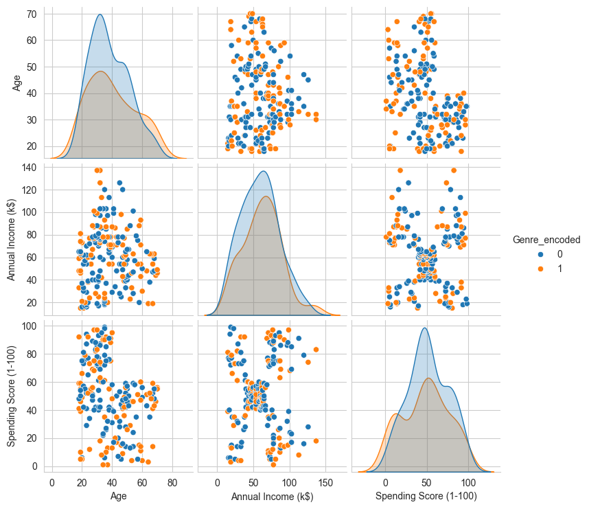

```python
# Pairplot to see relationships
sns.pairplot(
    df[["Genre_encoded", "Age", "Annual Income (k$)", "Spending Score (1-100)"]],
    diag_kind="kde",
    hue="Genre_encoded"
)
plt.show()
```

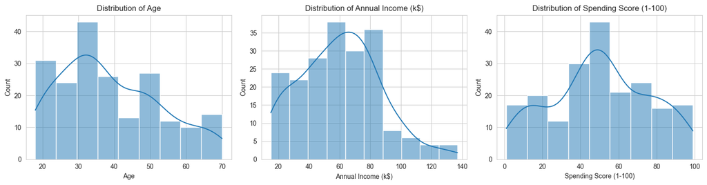

```python
# Histograms
cols = ["Age", "Annual Income (k$)", "Spending Score (1-100)"]
fig, axes = plt.subplots(1, 3, figsize=(15, 4))

for i, col in enumerate(cols):
    sns.histplot(df[col], ax=axes[i], kde=True)
    axes[i].set_title(f"Distribution of {col}")

plt.tight_layout()
plt.show()
```

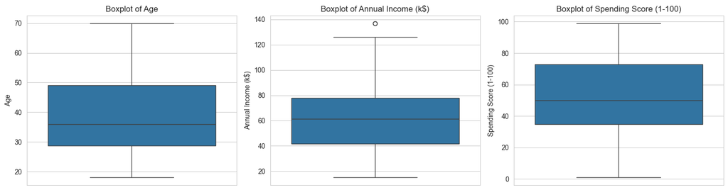

```python
# Boxplots
fig, axes = plt.subplots(1, 3, figsize=(15, 4))
for i, col in enumerate(cols):
    sns.boxplot(y=df[col], ax=axes[i])
    axes[i].set_title(f"Boxplot of {col}")

plt.tight_layout()
plt.show()
```

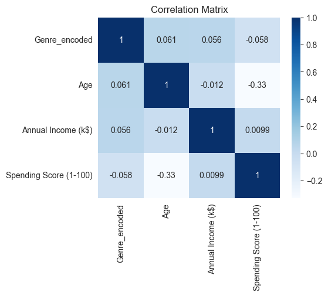

```python
# Correlation matrix
corr = df[["Genre_encoded", "Age", "Annual Income (k$)", "Spending Score (1-100)"]].corr()
plt.figure(figsize=(5,4))
sns.heatmap(corr, annot=True, cmap="Blues")
plt.title("Correlation Matrix")
plt.show()
```

### 3.3 Data Transformation & Scaling

Clustering often benefits from data scaling to avoid bias towards features with larger numeric ranges. We'll use **StandardScaler** on selected columns for demonstration:

- `Age`
- `Annual Income (k$)`
- `Spending Score (1-100)`

```python
features = ["Age", "Annual Income (k$)", "Spending Score (1-100)"]
X = df[features].copy()

scaler = StandardScaler()
X_scaled = scaler.fit_transform(X)

# If you want to include 'Genre_encoded':
# X2 = df[["Genre_encoded", "Age", "Annual Income (k$)", "Spending Score (1-100)"]]
# X_scaled2 = scaler.fit_transform(X2)
```

# 4. Clustering Methods

We'll apply three clustering algorithms:

- **K-Means**
- **Hierarchical Clustering**
- **DBSCAN**

Then we'll compare the results using metrics like the **Elbow Method**, **Silhouette Score**, and visual inspection.

## 4.1 K-means Clustering

1. Use the **Elbow Method** to determine a good candidate for the number of clusters (k).
2. Validate with **Silhouette Scores**.
3. Assign cluster labels and visualize via PCA.

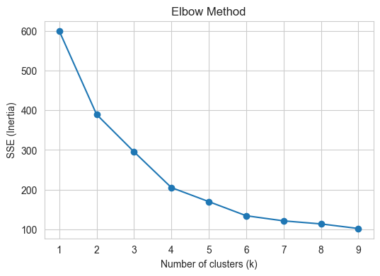

```python
# 4.1.1 Elbow Method
sse = []
k_range = range(1, 10)

for k in k_range:
    kmeans = KMeans(n_clusters=k, random_state=42)
    kmeans.fit(X_scaled)
    sse.append(kmeans.inertia_)

plt.figure(figsize=(6,4))
plt.plot(k_range, sse, marker="o")
plt.xlabel("Number of clusters (k)")
plt.ylabel("SSE (Inertia)")
plt.title("Elbow Method")
plt.show()
```

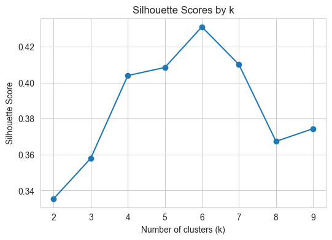

```
Best k based on Silhouette Score: 6
```

```python
# 4.1.2 Silhouette Scores
sil_scores = []
k_candidates = range(2, 10)  # Silhouette cannot be computed for k=1

for k in k_candidates:
    kmeans = KMeans(n_clusters=k, random_state=42)
    labels = kmeans.fit_predict(X_scaled)
    sil = silhouette_score(X_scaled, labels)
    sil_scores.append(sil)

plt.figure(figsize=(6,4))
plt.plot(k_candidates, sil_scores, marker="o")
plt.xlabel("Number of clusters (k)")
plt.ylabel("Silhouette Score")
plt.title("Silhouette Scores by k")
plt.show()

best_k = k_candidates[np.argmax(sil_scores)]
print("Best k based on Silhouette Score:", best_k)
```

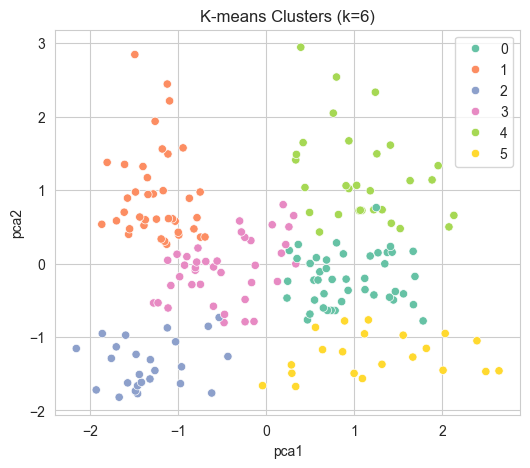

```python
# 4.1.3 K-means with best_k
kmeans = KMeans(n_clusters=best_k, random_state=42)
cluster_labels = kmeans.fit_predict(X_scaled)

df["Cluster_Kmeans"] = cluster_labels  # attach cluster labels to original df

# 2D Visualization: use PCA for dimensionality reduction
pca = PCA(n_components=2)
X_pca = pca.fit_transform(X_scaled)
df["pca1"] = X_pca[:, 0]
df["pca2"] = X_pca[:, 1]

plt.figure(figsize=(6,5))
sns.scatterplot(
    data=df,
    x="pca1",
    y="pca2",
    hue="Cluster_Kmeans",
    palette="Set2"
)
plt.title(f"K-means Clusters (k={best_k})")
plt.legend()
plt.show()
```

## 4.2 Hierarchical Clustering

We'll perform **Hierarchical Clustering** using `linkage` and then select clusters by cutting the dendrogram at a chosen distance.

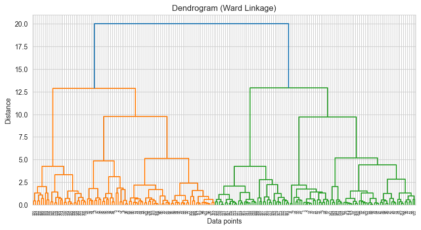

```python
# 4.2.1 Dendrogram
Z = linkage(X_scaled, method='ward')
plt.figure(figsize=(10,5))
dendrogram(Z)
plt.title("Dendrogram (Ward Linkage)")
plt.xlabel("Data points")
plt.ylabel("Distance")
plt.show()
```

```
Number of clusters (Hierarchical): 4
```

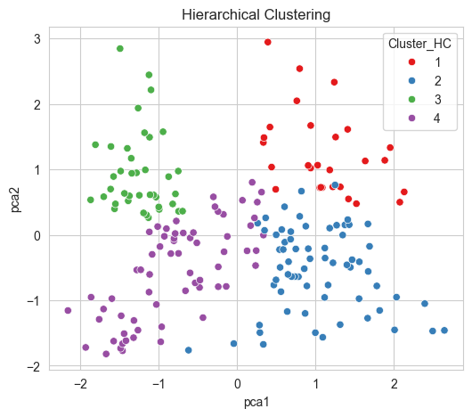

```python
# 4.2.2 Cut the dendrogram
max_d = 10  # Example threshold; choose based on the dendrogram
clusters_hc = fcluster(Z, max_d, criterion='distance')
df["Cluster_HC"] = clusters_hc

n_clusters_hc = len(np.unique(clusters_hc))
print("Number of clusters (Hierarchical):", n_clusters_hc)

# Plot with PCA components
plt.figure(figsize=(6,5))
sns.scatterplot(
    data=df,
    x="pca1",
    y="pca2",
    hue="Cluster_HC",
    palette="Set1"
)
plt.title("Hierarchical Clustering")
plt.show()
```

## 4.3 DBSCAN

**DBSCAN** requires careful tuning of parameters such as `eps` and `min_samples`. It's also sensitive to data scale.

```
DBSCAN cluster labels: [-1  0]
```

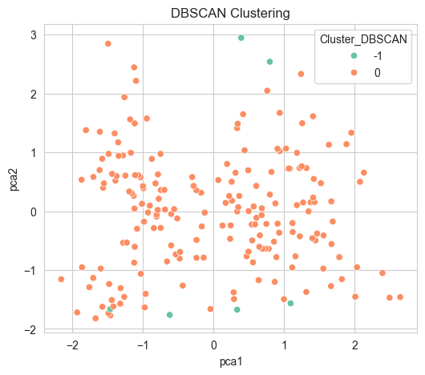

```python
# Example DBSCAN
dbscan = DBSCAN(eps=0.8, min_samples=5)
labels_db = dbscan.fit_predict(X_scaled)

df["Cluster_DBSCAN"] = labels_db
unique_labels = np.unique(labels_db)
print("DBSCAN cluster labels:", unique_labels)

plt.figure(figsize=(6,5))
sns.scatterplot(
    data=df,
    x="pca1",
    y="pca2",
    hue="Cluster_DBSCAN",
    palette="Set2"
)
plt.title("DBSCAN Clustering")
plt.show()
```

### 4.3.1 DBSCAN Parameter Tuning

We can try multiple values of `eps` to see how the number of clusters (and outliers) changes.

```python
eps_values = [0.5, 0.7, 0.9, 1.1, 1.3]
min_samples = 5

print("DBSCAN Parameter Tuning Results:")
for eps_val in eps_values:
    dbscan_test = DBSCAN(eps=eps_val, min_samples=min_samples)
    labels_test = dbscan_test.fit_predict(X_scaled)
    n_clusters_test = len(set(labels_test)) - (1 if -1 in labels_test else 0)
    n_outliers_test = (labels_test == -1).sum()
    print(f" eps = {eps_val}, #Clusters = {n_clusters_test}, Outliers = {n_outliers_test}")
```

```
DBSCAN Parameter Tuning Results:
 eps = 0.5, #Clusters = 6, Outliers = 60
 eps = 0.7, #Clusters = 1, Outliers = 14
 eps = 0.9, #Clusters = 1, Outliers = 3
 eps = 1.1, #Clusters = 1, Outliers = 0
 eps = 1.3, #Clusters = 1, Outliers = 0
```

## 5. Comparison and Discussion

**K-means**:

**Hierarchical Clustering**:

- Method: Ward, complete, average, etc.
- Number of clusters determined by dendrogram threshold or `maxclust`.

**DBSCAN**:

- Parameters: `eps`, `min_samples`
- Number of clusters (excluding noise points) can vary significantly.

Analyze the results, cluster sizes, and potential outliers. You can create additional plots or tables to highlight cluster characteristics.

```python
# Example: Summaries of each cluster for K-means
print("\nCluster Means (K-means):")
print(df.groupby("Cluster_Kmeans")[features].mean())

# Summaries of each cluster for Hierarchical Clustering
print("\nCluster Means (Hierarchical):")
print(df.groupby("Cluster_HC")[features].mean())

# Count how many points in each cluster
print("\nCluster Counts (K-means):")
print(df["Cluster_Kmeans"].value_counts())
print("\nCluster Counts (HC):")
print(df["Cluster_HC"].value_counts())
print("\nCluster Counts (DBSCAN):")
print(df["Cluster_DBSCAN"].value_counts())
```

```
Cluster Means (K-means):
                      Age  Annual Income (k$)  Spending Score (1-100)
Cluster_Kmeans
0               56.333333           54.266667               49.066667
1               32.692308           86.538462               82.128205
2               25.560000           26.480000               76.240000
3               26.125000           59.425000               44.450000
4               44.000000           90.133333               17.933333
5               45.523810           26.285714               19.380952

Cluster Means (Hierarchical):
                  Age  Annual Income (k$)  Spending Score (1-100)
Cluster_HC
1           43.892857           91.285714               16.678571
2           52.432836           45.597015               39.134328
3           32.692308           86.538462               82.128205
4           26.560606           47.363636               56.787879

Cluster Counts (K-means):
Cluster_Kmeans
0    45
3    40
1    39
4    30
2    25
5    21
Name: count, dtype: int64

Cluster Counts (HC):
Cluster_HC
2    67
4    66
3    39
1    28
Name: count, dtype: int64

Cluster Counts (DBSCAN):
Cluster_DBSCAN
 0    194
-1      6
Name: count, dtype: int64
```

# 6. Extended Conclusion and Insights